# **Introduction to Open Data Science, Exercise Set 2**

Regression and model validation

This set consists of a few numbered exercises. Go to each exercise in turn and do as follows:

1. Read the brief description of the exercise.
2. Run the (possible) pre-exercise-code chunk.
3. Follow the instructions to fix the R code!

## 2.0 INSTALL THE REQUIRED PACKAGES FIRST!

One or more extra packages (in addition to `tidyverse`) will be needed below.

```r
# Select (with mouse or arrow keys) the install.packages("...") and
# run it (by Ctrl+Enter / Cmd+Enter):

# install.packages("GGally")
```

## 2.1 Reading data from the web

The first step of data analysis with R is reading data into R. This is done with a function. Which function and function arguments to use to do this, depends on the original format of the data.

Conveniently in R, the same functions for reading data can usually be used whether the data is saved locally on your computer or somewhere else behind a web URL.

After the correct function has been identified and data read into R, the data will usually be in R `data.frame` format. Te dimensions of a data frame are ($n$,$d$), where $n$ is the number of rows (the observations) and $d$ the number of columns (the variables).

**The purpose of this course is to expose you to some basic and more advanced tasks of programming and data analysis with R.**

### Instructions

- Read the `lrn14` data frame to memory with `read.table()`. There is information related to the data [here](http://www.helsinki.fi/~kvehkala/JYTmooc/JYTOPKYS3-meta.txt)
- Use `dim()` on the data frame to look at the dimensions of the data. How many rows and colums does the data have?
- Look at the structure of the data with `str()`.

Hint: - For both functions you can pass a data frame as the first (unnamed) argument.

### R code

```r
# This is a code chunk in RStudio editor.
# Work with the exercise in this chunk, step-by-step. Fix the R code!

# read the data into memory
lrn14 <- read.table("http://www.helsinki.fi/~kvehkala/JYTmooc/JYTOPKYS3-data.txt", sep="\t", header=TRUE)

# Look at the dimensions of the data

dim(lrn14)
```

```
## [1] 183  60
```

```r
# Look at the structure of the data

str(lrn14)
```

```
## 'data.frame':    183 obs. of  60 variables:
##  $ Aa      : int  3 2 4 4 3 4 4 3 2 3 ...
##  $ Ab      : int  1 2 1 2 2 2 1 1 1 2 ...
##  $ Ac      : int  2 2 1 3 2 1 2 2 2 1 ...
##  $ Ad      : int  1 2 1 2 1 1 2 1 1 1 ...
##  $ Ae      : int  1 1 1 1 2 1 1 1 1 1 ...
##  $ Af      : int  1 1 1 1 1 1 1 1 1 2 ...
##  $ ST01    : int  4 4 3 3 4 4 5 4 4 4 ...
##  $ SU02    : int  2 2 1 3 2 3 2 2 1 2 ...
##  $ D03     : int  4 4 4 4 5 5 4 4 5 4 ...
##  $ ST04    : int  4 4 4 4 3 4 2 5 5 4 ...
##  $ SU05    : int  2 4 2 3 4 3 2 4 2 4 ...
##  $ D06     : int  4 2 3 4 4 5 3 3 4 4 ...
##  $ D07     : int  4 3 4 4 4 5 4 4 5 4 ...
##  $ SU08    : int  3 4 1 2 3 4 4 2 4 2 ...
```

[output cut: 46 more lines]

## 2.2 Scaling variables

The next step is [wrangling the data](https://en.wikipedia.org/wiki/Data_wrangling) into a format that is easy to analyze. We will wrangle our data for the next few exercises.

A neat thing about R is that may operations are *vectorized*. It means that a single operation can affect all elements of a vector. This is often convenient.

The column `Attitude` in `lrn14` is a sum of 10 questions related to students attitude towards statistics, each measured on the [Likert scale](https://en.wikipedia.org/wiki/Likert_scale) (1-5). Here we’ll scale the combination variable back to the 1-5 scale.

### Instructions

- Execute the example codes to see how vectorized division works
- Use vector division to create a new column `attitude` in the `lrn14` data frame, where each observation of `Attitude` is scaled back to the original scale of the questions, by dividing it with the number of questions.

Hint: - Assign ‘Attitude divided by 10’ to the new column ’attitude.

### R code

```r
# This is a code chunk in RStudio editor.
# Work with the exercise in this chunk, step-by-step. Fix the R code!

#lrn14 is available

# divide each number in a vector
c(1,2,3,4,5) / 2
```

```
## [1] 0.5 1.0 1.5 2.0 2.5
```

```r
# print the "Attitude" column vector of the lrn14 data
lrn14$Attitude
```

```
##   [1] 37 31 25 35 37 38 35 29 38 21 39 38 24 30 26 25 41 26 26 17 27 39 34 27 23
##  [26] 37 44 41 24 37 25 30 34 32 20 24 42 16 31 38 38 33 17 25 32 35 32 42 31 39
##  [51] 19 21 25 32 32 26 23 38 28 33 48 40 40 47 23 31 27 41 34 34 25 21 14 19 37
##  [76] 41 32 28 41 25 28 38 31 35 36 26 44 45 32 20 39 25 33 35 33 30 29 33 33 35
## [101] 36 42 37 28 42 22 32 50 47 36 36 29 35 40 35 32 26 20 27 32 33 39 33 30 37
## [126] 14 30 25 29 39 36 29 21 31 24 40 31 23 28 37 26 24 30 29 32 28 29 24 31 19
## [151] 20 38 34 37 29 23 41 27 35 34 32 33 33 35 32 31 24 28 17 19 32 35 24 38 21
## [176] 29 19 20 42 41 37 36 18
```

```r
# divide each number in the column vector
lrn14$Attitude / 10
```

```
##   [1] 3.7 3.1 2.5 3.5 3.7 3.8 3.5 2.9 3.8 2.1 3.9 3.8 2.4 3.0 2.6 2.5 4.1 2.6
##  [19] 2.6 1.7 2.7 3.9 3.4 2.7 2.3 3.7 4.4 4.1 2.4 3.7 2.5 3.0 3.4 3.2 2.0 2.4
##  [37] 4.2 1.6 3.1 3.8 3.8 3.3 1.7 2.5 3.2 3.5 3.2 4.2 3.1 3.9 1.9 2.1 2.5 3.2
##  [55] 3.2 2.6 2.3 3.8 2.8 3.3 4.8 4.0 4.0 4.7 2.3 3.1 2.7 4.1 3.4 3.4 2.5 2.1
##  [73] 1.4 1.9 3.7 4.1 3.2 2.8 4.1 2.5 2.8 3.8 3.1 3.5 3.6 2.6 4.4 4.5 3.2 2.0
##  [91] 3.9 2.5 3.3 3.5 3.3 3.0 2.9 3.3 3.3 3.5 3.6 4.2 3.7 2.8 4.2 2.2 3.2 5.0
## [109] 4.7 3.6 3.6 2.9 3.5 4.0 3.5 3.2 2.6 2.0 2.7 3.2 3.3 3.9 3.3 3.0 3.7 1.4
## [127] 3.0 2.5 2.9 3.9 3.6 2.9 2.1 3.1 2.4 4.0 3.1 2.3 2.8 3.7 2.6 2.4 3.0 2.9
## [145] 3.2 2.8 2.9 2.4 3.1 1.9 2.0 3.8 3.4 3.7 2.9 2.3 4.1 2.7 3.5 3.4 3.2 3.3
## [163] 3.3 3.5 3.2 3.1 2.4 2.8 1.7 1.9 3.2 3.5 2.4 3.8 2.1 2.9 1.9 2.0 4.2 4.1
## [181] 3.7 3.6 1.8
```

```r
# create column 'attitude' by scaling the column "Attitude"
lrn14$attitude <- lrn14$Attitude / 10

View(lrn14)
```

## 2.3 Combining variables

Our data includes many questions that can be thought to measure the same *dimension*. You can read more about the data and the variables [here](http://www.helsinki.fi/~kvehkala/JYTmooc/JYTOPKYS3-meta.txt). Here we’ll combine multiple questions into combination variables. Useful functions for summation with data frames in R are

| function | description |
| --- | --- |
| `colSums(df)` | returns a sum of each column in `df` |
| `rowSums(df)` | returns a sum of each row in `df` |
| `colMeans(df)` | returns the mean of each column in `df` |
| `rowMeans(df)` | return the mean of each row in `df` |

We’ll combine the use of `rowMeans()`with the `select()` function from the **dplyr** library to average the answers of selected questions. See how it is done from the example codes.

### Instructions

- Access the **dplyr** library
- Execute the example codes to create the combination variables ‘deep’ and ‘surf’ as columns in `lrn14`
- Select the columns related to strategic learning from `lrn14`
- Create the combination variable ‘stra’ as a column in `lrn14`

Hints: - Columns related to strategic learning are in the object `strategic_questions`. Use it for selecting the correct columns. - Use the function `rowMeans()` identically to the examples

### R code

```r
# Work with the exercise in this chunk, step-by-step. Fix the R code!
# lrn14 is available

# Access the dplyr library
library(dplyr)
# questions related to deep, surface and strategic learning
deep_questions <- c("D03", "D11", "D19", "D27", "D07", "D14", "D22", "D30","D06",  "D15", "D23", "D31")
surface_questions <- c("SU02","SU10","SU18","SU26", "SU05","SU13","SU21","SU29","SU08","SU16","SU24","SU32")
strategic_questions <- c("ST01","ST09","ST17","ST25","ST04","ST12","ST20","ST28")

# select the columns related to deep learning
deep_columns <- select(lrn14, one_of(deep_questions))
# and create column 'deep' by averaging
lrn14$deep <- rowMeans(deep_columns)

# select the columns related to surface learning
surface_columns <- select(lrn14, one_of(surface_questions))
# and create column 'surf' by averaging
lrn14$surf <- rowMeans(surface_columns)

# select the columns related to strategic learning
strategic_columns <- select(lrn14, one_of(strategic_questions))
# and create column 'stra' by averaging
lrn14$stra <- rowMeans(strategic_columns)


View(lrn14)
```

## 2.4 Selecting columns

Often it is convenient to work with only a certain column or a subset of columns of a bigger data frame. There are many ways to select columns of data frame in R and you saw one of them in the previous exercise: `select()` from **dplyr***.

**dplyr** is a popular library for *data wrangling*. There are also convenient [data wrangling cheatsheets by RStudio](https://www.rstudio.com/resources/cheatsheets/) to help you get started (dplyr, tidyr etc.)

### Instructions

- Access the **dplyr** library
- Create object `keep_columns`
- Use `select()` (possibly together with `one_of()`) to create a new data frame `learning2014` with the columns named in `keep_columns`.
- Look at the structure of the new dataset

Hint: - See the previous exercise or the data wrangling cheatsheet for help on how to select columns

### R code

```r
# Work with the exercise in this chunk, step-by-step. Fix the R code!

# lrn14 is available

# access the dplyr library
library(dplyr)

# choose a handful of columns to keep
keep_columns <- c("gender","Age","attitude", "deep", "stra", "surf", "Points")

# select the 'keep_columns' to create a new dataset
learning2014 <- keep_columns

# see the structure of the new dataset

str(learning2014)
```

```
##  chr [1:7] "gender" "Age" "attitude" "deep" "stra" "surf" "Points"
```

## 2.5 Modifying column names

Sometimes you want to rename your colums. You could do this by creating copies of the columns with new names, but you can also directly get and set the column names of a data frame, using the function `colnames()`.

The **dplyr** library has a `rename()` function, which can also be used. Remember [the cheatsheets](https://www.rstudio.com/resources/cheatsheets/).

### Instructions

- Print out the column names of `learning2014`
- Change the name of the second column to ‘age’
- Change the name of ‘Points’ to ‘points’
- Print out the column names again to see the changes

Hint: - You can use `colnames()` similarily to the example. Which index matches the column ‘Points’?

### R code

```r
# Work with the exercise in this chunk, step-by-step. Fix the R code!
# learning2014 is available

# print out the column names of the data
colnames(learning2014)
```

```
## [1] "gender"   "Age"      "attitude" "deep"     "stra"     "surf"     "Points"
```

```r
# change the name of the second column
colnames(learning2014)[2] <- "age"

# change the name of "Points" to "points"
colnames(learning2014)[7] <- "points"

# print out the new column names of the data
colnames(learning2014)
```

```
## [1] "gender"   "age"      "attitude" "deep"     "stra"     "surf"     "points"
```

## 2.6 Excluding observations

Often your data includes outliers or other observations which you wish to remove before further analysis. Or perhaps you simply wish to work with some subset of your data.

In the **learning2014** data the variable ‘points’ denotes the students exam points in a statistics course exam. If the student did not attend an exam, the value of ‘points’ will be zero. We will remove these observations from the data.

### Instructions

- Access the **dplyr** library
- As an example, create object `male_students` by selecting the male students from `learning2014`
- Override `learning2014` and select rows where the ‘points’ variable is greater than zero.
- If you do not remember how logical comparison works in R, see the ‘Logical comparison’ exercise from the course ‘R Short and Sweet’.

Hint: - The “greater than” logical operator is `>`

### R code

```r
# Work with the exercise in this chunk, step-by-step. Fix the R code!
# learning2014 is available

# access the dplyr library
library(dplyr)

# select male students
male_students <- filter(learning2014, gender == "M")

# select rows where points is greater than zero
learning2014 <- filter(learning2014, points > 0)

View(learning2014)
```

## 2.7 Visualizations with ggplot2

[**ggplot2**](http://ggplot2.org/) is a popular library for creating stunning graphics with R. It has some advantages over the basic plotting system in R, mainly consistent use of function arguments and flexible plot alteration. ggplot2 is an implementation of Leland Wilkinson’s *Grammar of Graphics* — a general scheme for data visualization.

In ggplot2, plots may be created via the convenience function `qplot()` where arguments and defaults are meant to be similar to base R’s `plot()` function. More complex plotting capacity is available via `ggplot()`, which exposes the user to more explicit elements of the grammar. (from [wikipedia](https://en.wikipedia.org/wiki/Ggplot2))

RStudio has a [cheatsheet](https://www.rstudio.com/resources/cheatsheets/) for data visualization with ggplot2.

### Instructions

- Access the **ggplot2** library
- Initialize the plot with data and aesthetic mappings
- Adjust the plot initialization: Add an aesthetic element to the plot by defining `col = gender` inside `aes()`.
- Define the visualization type (points)
- Draw the plot to see how it looks at this point
- *Add* a regression line to the plot
- *Add* the title “Student’s attitude versus exam points” with `ggtitle("<insert title here>")` to the plot with regression line
- Draw the plot again to see the changes

Hints: - Use `+` to add the title to the plot - The plot with regression line is saved in the object `p3` - You can draw the plot by typing the object name where the plot is saved

### R code

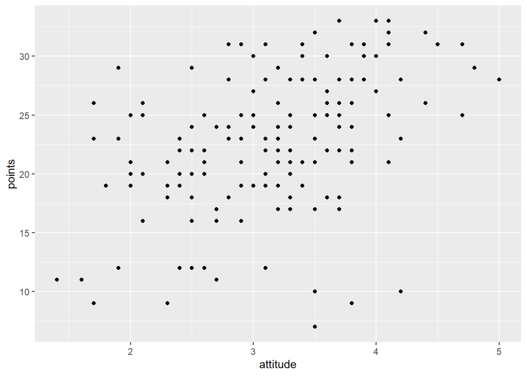

```r
# Work with the exercise in this chunk, step-by-step. Fix the R code!
# learning2014 is available

# Access the gglot2 library
library(ggplot2)

# initialize plot with data and aesthetic mapping
p1 <- ggplot(learning2014, aes(x = attitude, y = points))

# define the visualization type (points)
p2 <- p1 + geom_point()

# draw the plot
p2
```

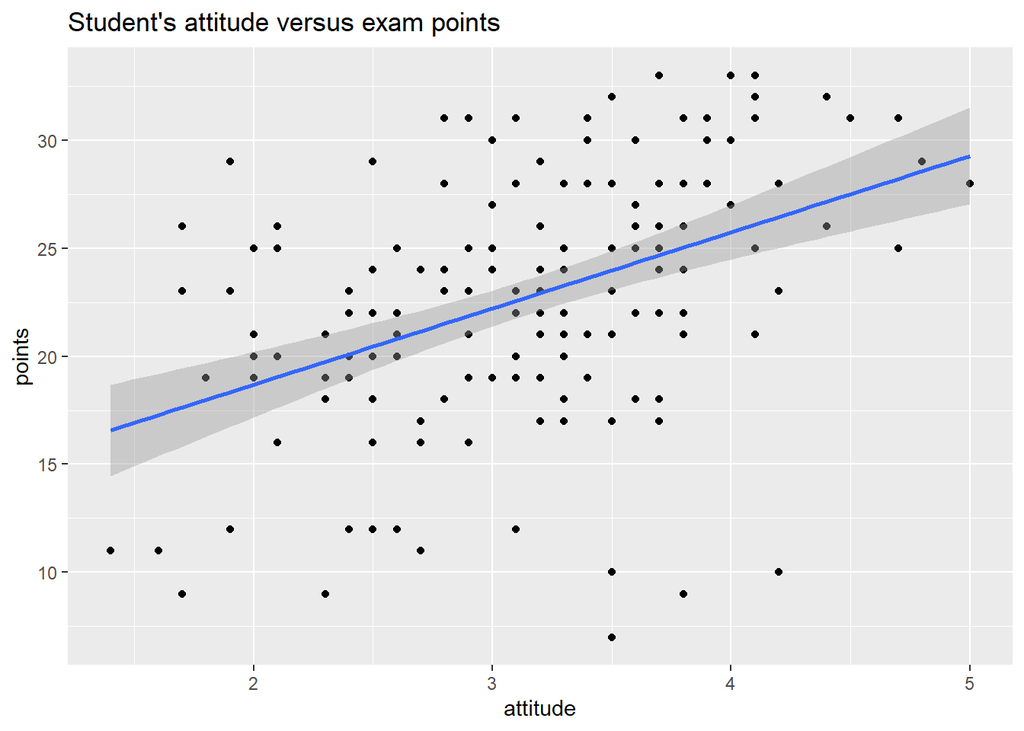

```r
# add a regression line
p3 <- p2 + geom_smooth(method = "lm")

# add a main title
p4 <- p3 + ggtitle("Student's attitude versus exam points")

# draw the plot!
p4
```

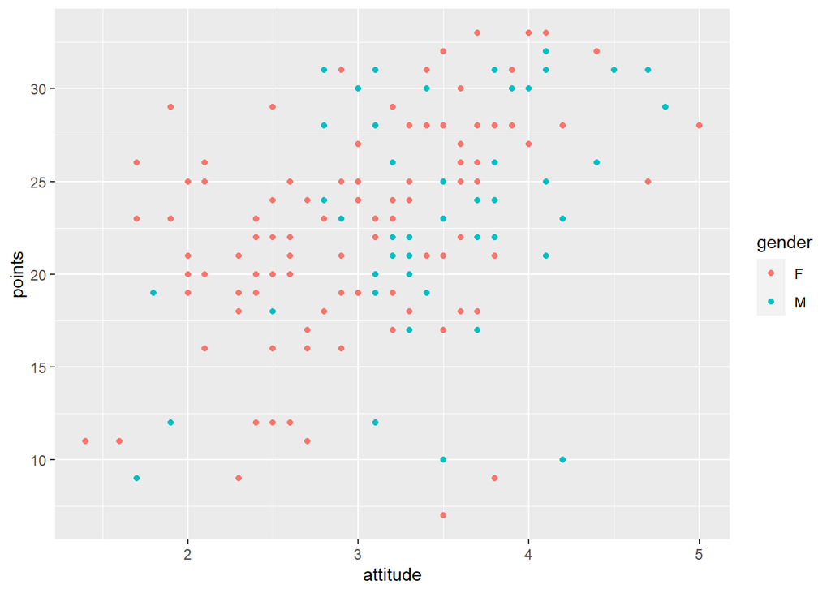

```r
# with the variable: Gender

# initialize plot with data and aesthetic mapping
p1 <- ggplot(learning2014, aes(x = attitude, y = points, col = gender))

# define the visualization type (points)
p2 <- p1 + geom_point()

# draw the plot
p2
```

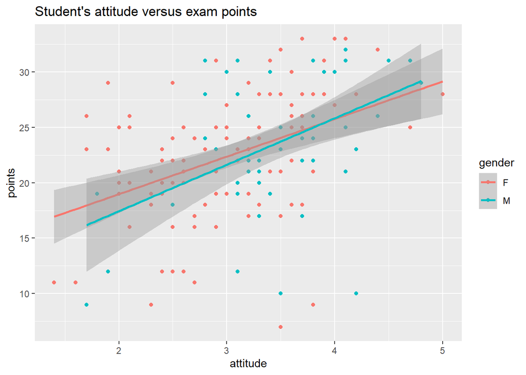

```r
# add a regression line
p3 <- p2 + geom_smooth(method = "lm")

# add a main title
p4 <- p3 + ggtitle("Student's attitude versus exam points")

# draw the plot!
p4
```

## 2.8 Exploring a data frame

Often the most interesting feature of your data are the relationships between the variables. If there are only a handful of variables saved as columns in a data frame, it is possible to visualize all of these relationships neatly in a single plot.

Base R offers a fast plotting function `pairs()`, which draws all possible scatter plots from the columns of a data frame, resulting in a scatter plot matrix. Libraries **GGally** and **ggplot2** together offer a slow but more detailed look at the variables, their distributions and relationships.

### Instructions

- Draw a scatter matrix of the variables in learning2014 (other than gender)
- Adjust the code: Add the argument `col` to the `pairs()` function, defining the colour with the ‘gender’ variable in learning2014.
- Draw the plot again to see the changes.
- Access the **ggpot2** and **GGally** libraries and create the plot `p` with `ggpairs()`.
- Draw the plot. Note that the function is a bit slow.
- Adjust the argument `mapping` of `ggpairs()` by defining `col = gender` inside `aes()`.
- Draw the plot again.
- Adjust the code a little more: add another aesthetic element `alpha = 0.3` inside `aes()`.
- See the difference between the plots?

Hints: - You can use `$` to access a column of a data frame. - Remember to separate function arguments with a comma - You can draw the plot `p` by simply typing it’s name: just like printing R objects.

### R code

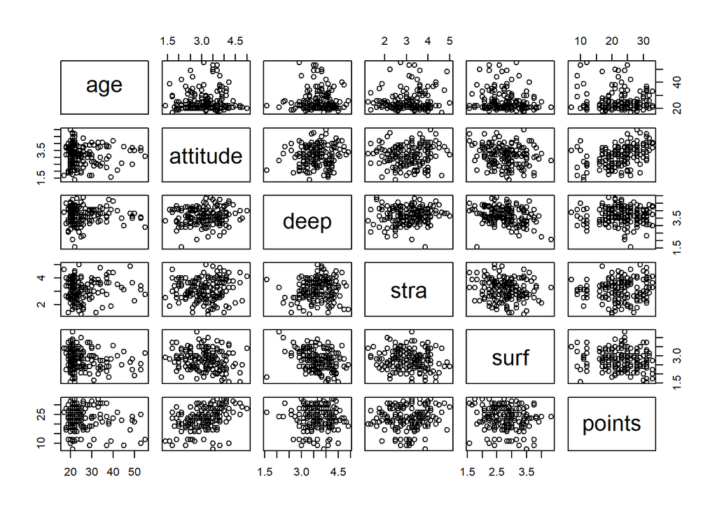

```r
# Work with the exercise in this chunk, step-by-step. Fix the R code!
# learning2014 is available

# draw a scatter plot matrix of the variables in learning2014.
# [-1] excludes the first column (gender)
pairs(learning2014[-1])
```

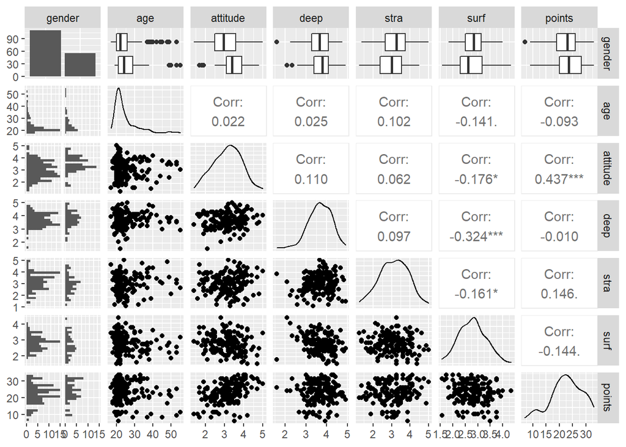

```r
# access the GGally and ggplot2 libraries
library(GGally)
library(ggplot2)

# create a more advanced plot matrix with ggpairs()
p <- ggpairs(learning2014, mapping = aes(), lower = list(combo = wrap("facethist", bins = 20)))

# draw the plot

p
```

## 2.9 Simple regression

[Regression analysis](https://en.wikipedia.org/wiki/Regression_analysis) with R is easy once you have your data in a neat data frame. You can simply use the `lm()` function to fit a linear model. The first argument of `lm()` is a `formula`, which defines the target variable and the explanatory variable(s).

The formula should be `y ~ x`, where `y` is the target (or outcome) variable and `x` the explanatory variable (predictor). The second argument of `lm()` is `data`, which should be a data frame where `y` and `x` are columns.

The output of `lm()` is a linear model object, which can be saved for later use. The generic function `summary()` can be used to print out a summary of the model.

### Instructions

- Create a scatter plot of ‘points’ versus ‘attitude’.
- Fit a regression model where ‘points’ is the target and ‘attitude’ is the explanatory variable
- Print out the summary of the linear model object

Hints: - Replace `1` with the name of the explanatory variable in the formula inside `lm()` - Use `summary()` on the model object to print out a summary

### R code

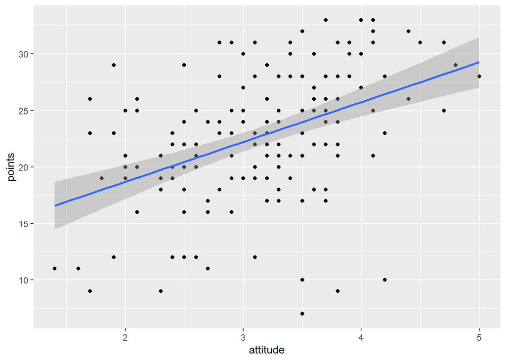

```r
# Work with the exercise in this chunk, step-by-step. Fix the R code!
# learning2014 is available

# a scatter plot of points versus attitude
library(ggplot2)
qplot(attitude, points, data = learning2014) + geom_smooth(method = "lm")
```

```r
# fit a linear model
my_model <- lm(points ~ attitude, data = learning2014)

# print out a summary of the model
my_model
```

```
##
## Call:
## lm(formula = points ~ attitude, data = learning2014)
##
## Coefficients:
## (Intercept)     attitude
##      11.637        3.525
```

## 2.10 Multiple regression

When there are more than one explanatory variables in the linear model, it is called multiple regression. In R, it is easy to include more than one explanatory variables in your linear model. This is done by simply defining more explanatory variables with the `formula` argument of `lm()`, as below

```
y ~ x1 + x2 + ..
```

Here `y` is again the target variable and `x1, x2, ..` are the explanatory variables.

### Instructions

- Draw a plot matrix of the learning2014 data with `ggpairs()`
- Fit a regression model where `points` is the target variable and both `attitude` and `stra` are the explanatory variables.
- Print out a summary of the model.
- Adjust the code: Add one more explanatory variable to the model. Based on the plot matrix, choose the variable with the third highest (absolute) correlation with the target variable and use that as the third variable.
- Print out a summary of the new model.

Hint: - The variable with the third highest absolute correlation with `points` is `surf`.

### R code

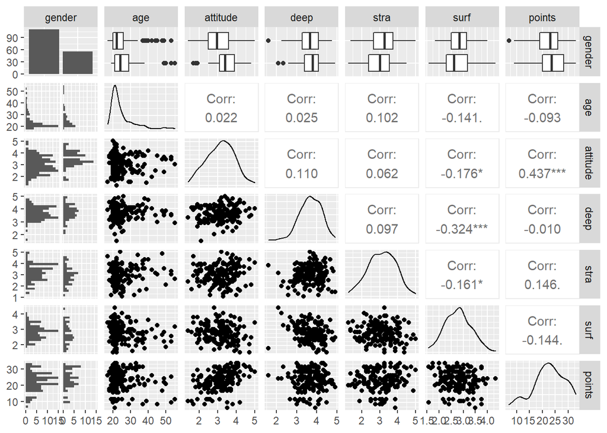

```r
# Work with the exercise in this chunk, step-by-step. Fix the R code!
# learning2014 is available

library(GGally)
library(ggplot2)
# create an plot matrix with ggpairs()
ggpairs(learning2014, lower = list(combo = wrap("facethist", bins = 20)))
```

```r
# create a regression model with multiple explanatory variables
my_model2 <- lm(points ~ attitude + stra, data = learning2014)

# print out a summary of the model
my_model2
```

```
##
## Call:
## lm(formula = points ~ attitude + stra, data = learning2014)
##
## Coefficients:
## (Intercept)     attitude         stra
##      8.9729       3.4658       0.9137
```

```r
# three variable model

# create a regression model with multiple explanatory variables
my_model3 <- lm(points ~ attitude + stra + surf, data = learning2014)

# print out a summary of the model
my_model3
```

```
##
## Call:
## lm(formula = points ~ attitude + stra + surf, data = learning2014)
##
## Coefficients:
## (Intercept)     attitude         stra         surf
##     11.0171       3.3952       0.8531      -0.5861
```

## 2.11 Graphical model validation

R makes it easy to graphically explore the validity of your model assumptions. If you give a linear model object as the first argument to the `plot()` function, the function automatically assumes you want diagnostic plots and will produce them. You can check the help page of plotting an lm object by typing `?plot.lm` or `help(plot.lm)` to the R console.

In the plot function you can then use the argument `which` to choose which plots you want. `which` must be an integer vector corresponding to the following list of plots:

| which | graphic |
| --- | --- |
| 1 | Residuals vs Fitted values |
| 2 | Normal QQ-plot |
| 3 | Standardized residuals vs Fitted values |
| 4 | Cook’s distances |
| 5 | Residuals vs Leverage |
| 6 | Cook’s distance vs Leverage |

We will focus on plots 1, 2 and 5: Residuals vs Fitted values, Normal QQ-plot and Residuals vs Leverage.

### Instructions

- Create the linear model object `my_model2`
- Produce the following diagnostic plots using the `plot()` function: Residuals vs Fitted values, Normal QQ-plot and Residuals vs Leverage using the argument `which`.
- Before the call to the `plot()` function, add the following: `par(mfrow = c(2,2))`. This will place the following 4 graphics to the same plot. Execute the code again to see the effect.

Hint: - You can combine integers to an integer vector with `c()`. For example: `c(1,2,3)`.

### R code

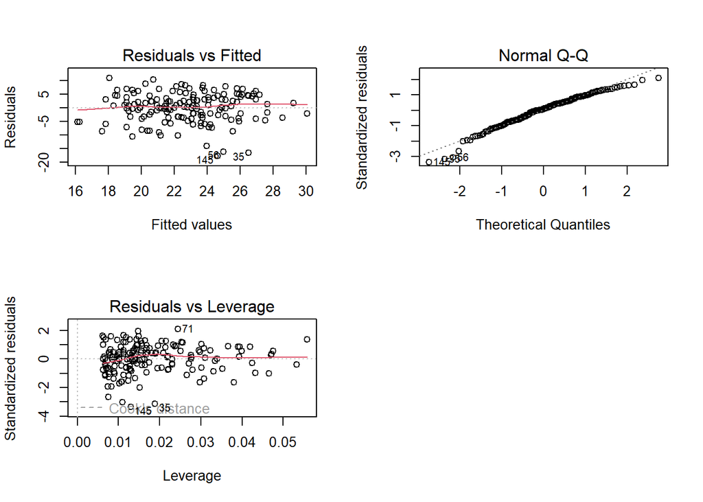

```r
# Work with the exercise in this chunk, step-by-step. Fix the R code!
# learning2014 is available

# create a regression model with multiple explanatory variables
my_model2 <- lm(points ~ attitude + stra, data = learning2014)

# draw diagnostic plots using the plot() function. Choose the plots 1, 2 and 5
par(mfrow = c(2,2))
plot(my_model2, which = c(1,2,5))
```

## 2.12 Making predictions

Okay, so let’s assume that we have a linear model which seems to fit our standards. What can we do with it?

The model quantifies the relationship between the explanatory variable(s) and the dependent variable. The model can also be used for predicting the dependent variable based on new observations of the explanatory variable(s).

In R, predicting can be done using the `predict()` function. (see `?predict`). The first argument of predict is a model object and the argument `newdata` (a data.frame) can be used to make predictions based on new observations. One or more columns of `newdata` should have the same name as the explanatory variables in the model object.

### Instructions

- Create object `m` and print out a summary of the model
- Create object `new_attitudes`
- Adjust the code: Create a new data frame with a column named ‘attitude’ holding the new attitudes defined in `new_attitudes`
- Print out the new data frame
- `predict()` the new student’s exam points based on their attitudes, using the `newdata` argument

Hints: - Type `attitude = new_attitudes` inside the `data.frame()` function. - Give the `new_data` data.frame as the `newdata` argument for `predict()`

### R code

```r
# Work with the exercise in this chunk, step-by-step. Fix the R code!
# learning2014 is available

# Create model object m
m <- lm(points ~ attitude, data = learning2014)

# print out a summary of the model
m
```

```
##
## Call:
## lm(formula = points ~ attitude, data = learning2014)
##
## Coefficients:
## (Intercept)     attitude
##      11.637        3.525
```

```r
# New observations
new_attitudes <- c("Mia" = 3.8, "Mike"= 4.4, "Riikka" = 2.2, "Pekka" = 2.9)
new_data <- data.frame(attitude = new_attitudes)

# Print out the new data
new_data
```

```
##        attitude
## Mia         3.8
## Mike        4.4
## Riikka      2.2
## Pekka       2.9
```

```r
# Predict the new students exam points based on attitude
predict(m, newdata = new_data)
```

```
##      Mia     Mike   Riikka    Pekka
## 25.03390 27.14918 19.39317 21.86099
```

**Awesome work!**